# R Notebook

```r
library(rpart)
library(rpart.plot)
```

```r
summary(m.rpart)
```

```
Call:
rpart(formula = CrimeRate ~ ExpenditureYear + StateSize + BelowWage +
    MatureUnemployment + Education + LabourForce, data = crime)
  n= 47

          CP nsplit rel error    xerror      xstd
1 0.39334682      0 1.0000000 1.0342956 0.1767026
2 0.09454168      1 0.6066532 0.7205975 0.1202818
3 0.06050197      2 0.5121115 0.7713918 0.1645535
4 0.01000000      3 0.4516095 0.7292024 0.1656147

Variable importance
   ExpenditureYear          BelowWage          StateSize
                34                 18                 17
MatureUnemployment          Education        LabourForce
                12                 10                  9

Node number 1: 47 observations,    complexity param=0.3933468
  mean=102.8085, MSE=817.0587
  left son=2 (23 obs) right son=3 (24 obs)
  Primary splits:
      ExpenditureYear    < 76.5  to the left,  improve=0.39334680, (0 missing)
      LabourForce        < 541   to the left,  improve=0.15475580, (0 missing)
      StateSize          < 48.5  to the left,  improve=0.11935310, (0 missing)
      MatureUnemployment < 27.5  to the left,  improve=0.10060020, (0 missing)
      BelowWage          < 248   to the right, improve=0.06924067, (0 missing)
  Surrogate splits:
      BelowWage          < 171.5 to the right, agree=0.745, adj=0.478, (0 split)
      MatureUnemployment < 28.5  to the left,  agree=0.702, adj=0.391, (0 split)
      StateSize          < 48.5  to the left,  agree=0.681, adj=0.348, (0 split)
      Education          < 11.55 to the left,  agree=0.638, adj=0.261, (0 split)
      LabourForce        < 593   to the right, agree=0.638, adj=0.261, (0 split)

Node number 2: 23 observations,    complexity param=0.09454168
  mean=84.49565, MSE=375.2891
  left son=4 (12 obs) right son=5 (11 obs)
  Primary splits:
      StateSize          < 22.5  to the left,  improve=0.42061100, (0 missing)
      ExpenditureYear    < 57.5  to the left,  improve=0.20123540, (0 missing)
      LabourForce        < 546.5 to the left,  improve=0.17402180, (0 missing)
```

[output cut: 21 more lines]

```
      Education          < 13.05 to the left,  agree=0.625, adj=0.182, (0 split)
      LabourForce        < 553.5 to the right, agree=0.625, adj=0.182, (0 split)
      MatureUnemployment < 35.5  to the right, agree=0.583, adj=0.091, (0 split)

Node number 4: 12 observations
  mean=72.46667, MSE=265.8972

Node number 5: 11 observations
  mean=97.61818, MSE=164.5742

Node number 6: 13 observations
  mean=111.3077, MSE=438.5299

Node number 7: 11 observations
  mean=131.0545, MSE=603.6934
```

Expenditure per year on police force was the most important variable, with the number of families below hlaf wage and the size of the state being the next important variables.

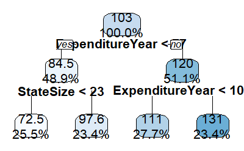

```r
rpart.plot(m.rpart, digits = 3, fallen.leaves = TRUE,tweak=1.3)
```

The regression tree shows that expenditure per year is the most important variable and is first splits observations by whether they are less than 77. The next node is state sizes that are less then 23. The third node is expenditure per year that is less 108. Observations where they spend more than 108 per capita on police have the highest crime rate.

5. When expenditure per year is less than 77 and state size is less than 23 the mean crime rate is 72.5. When expenditure per year is less than 77 and state size is greater than 23 the mean crime rate is 97.6. When expenditure per year is greater than 77 but less than 108 the mean crime rate is 111. When expenditure per year is greater than 108 the mean crime rate is 131.
6. Yes, BelowWage, LabourForce, MatureUnemployment, and Education were the variables that were excluded from the model. They were excluded from the model because based on the heterogeniety between groups. The function will try to minimize the sum of squared error at each split and exclude variables that have more noise.

```r
cor(p.rpart, crime10[["CrimeRate"]],method="pearson")
```

```
[1] 0.585602
```

The correlation coefficient is 0.58.

```r
MAE(predicted = p.rpart,actual = crime10[["CrimeRate"]])
```

```
[1] 25.28952
```

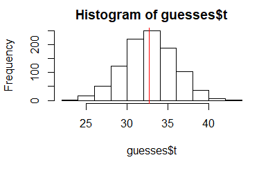

```r
MAE2 <- function(data,indices)  {
  d<-data[indices]
  return(mean(abs(actual - d)))
}
library(boot)
crimetest=crime[["CrimeRate"]]
actual=crimetest
guesses=boot(data=crimetest, statistic=MAE2, R=1000)
{hist(guesses$t)
abline(v=mean(guesses$t),col="red")}
```

```r
mean(guesses$t)
```

```
[1] 32.6533
```

11. The mean absolute error when states are randomly assigned crime rates is 32.65, which is greater than the mean error from the regression tree model (25.28).

```r
p.value
```

```
[1] 0
```

The mean abosolute error from the model is significantly different than the error from random chance (p=0).